# The effects of pseudoreplication on confidence intervals

## Simulations

We will first run simulations with a high number of groups (50 groups). We will then investigate whether the seriousness of pseudoreplication depends on how many groups we have in the data. Finally, we will investigate whether the seriousness of pseudoreplication depends on the among group variance.

Before we start, we need to load the `lme4` that contains the `lmer`function we will use to fit the mixed effects models (if this package is not installed, you will need to do so with `install.packages("lme4")`).

```r
library(lme4)
```

### Simulation with 50 groups:

First we simulate a single data set. We plot the data, fit both the correct model and the naive model, and compare 95% confidence intervals:

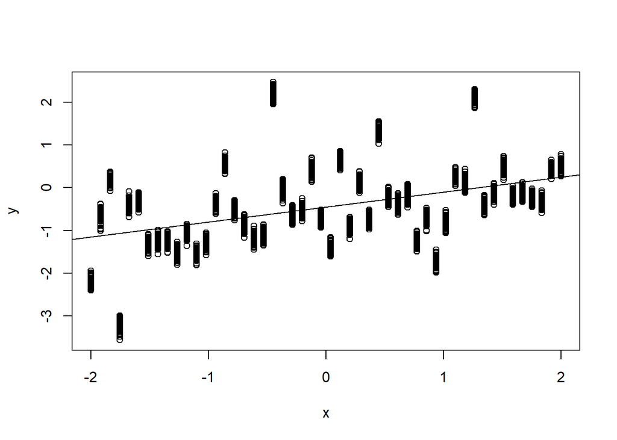

```r
set.seed(1234) # to reproduce the exact same result again
simdata = sim(50)
with(simdata, plot(y~x))
fit = fit.models(simdata)
abline(fit$naive$fit) # adding regression line to the plot
```

```r
fit$lmer$ci
```

```
##                  2.5 %     97.5 %
## .sig01              NA         NA
## .sigma              NA         NA
## (Intercept) -0.6967022 -0.2099442
## x            0.1442822  0.5574787
```

```r
fit$naive$ci
```

```
##                  2.5 %     97.5 %
## (Intercept) -0.4773365 -0.4293100
## x            0.3304962  0.3712647
```

```r
MC.covrate(50)
```

```
## $cr.lmer.int
## [1] 1
##
## $cr.lmer.slope
## [1] 1
##
## $cr.naive.int
## [1] 0.1
##
## $cr.naive.slope
## [1] 0.1
```

As seen here, the confidence intervals from the simple `lm()` model, ignoring the non-independence in the data, leads to confidence interval coverage rates way below the nominal 0.95 (i.e., the confidence intervals are too narrow).

It can be instructive to see that using only the mean responses for each group in a `lm()` model gives the correct coverage rates (not done here).

### Does the seriousness of pseudoreplication depend on number of groups?

Repeating the Monte Carlo simulations for number of groups equal to 5,10,20,50 and 100. This will take a bit of time (using sapply, so it can easily be parallelized later).

```r
N.groups = c(5,10,20,50,100)
covrates = sapply(N.groups, MC.covrate)
dimnames(covrates)[[2]] = N.groups
covrates
```

```
##                5   10  20  50  100
## cr.lmer.int    0.7 0.9 0.9 1   1
## cr.lmer.slope  0.8 0.8 0.8 1   1
## cr.naive.int   0.1 0.1 0.2 0   0.3
## cr.naive.slope 0.2 0.1 0.1 0.2 0.2
```

Plotting these

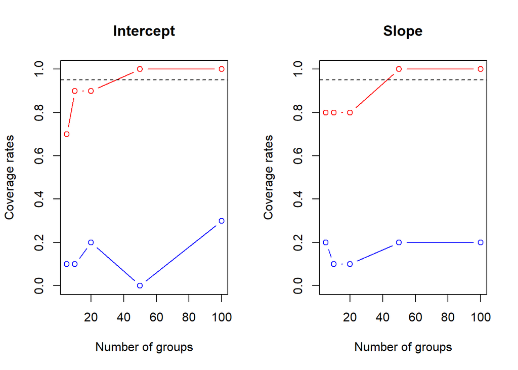

```r
par(mfrow=c(1,2))
plot(
  N.groups,
  unlist(covrates["cr.lmer.int",]),
  type="b",
  col="red",
  ylim=c(0,1),
  ylab="Coverage rates",
  xlab="Number of groups",
  main="Intercept"
  )
lines(
  N.groups,
  unlist(covrates["cr.naive.int",]),
  type="b",
  col="blue"
)
abline(h=0.95, lty=2)

plot(
  N.groups,
  unlist(covrates["cr.lmer.slope",]),
  type="b",
  col="red",
  ylim=c(0,1),
  ylab="Coverage rates",
  xlab="Number of groups",
  main="Slope"
)
lines(
  N.groups,
  unlist(covrates["cr.naive.slope",]),
  type="b",
  col="blue"
)
abline(h=0.95, lty=2)
```

This figure shows that ignoring random (unexplained) variation among groups (i.e. using pseudoreplication) is not less serious when there are many groups (as some seem to think). Also note that the Wald confidence intervals fail (are too narrow) also for `lmer` models when number of groups are small (one could try profile likelihood and bootstrap intervals, which I presume will do better).

### Does the seriousness of pseudoreplication depend on the among group variance?

We now keep 50 groups for all runs and instead vary the among group standard deviation ($\sigma_\delta^2$):

```r
sigmas = c(0, 0.01, 0.05,0.1,1,5)
MC.covrate.grsigma = function(grsigma, ...) MC.covrate(Ngr = 50, sigma.random = grsigma)
covrates = sapply(sigmas, MC.covrate.grsigma)
dimnames(covrates)[[2]] = sigmas
covrates
```

```
##                0 0.01 0.05 0.1 1   5
## cr.lmer.int    1 1    1    1   1   0.9
## cr.lmer.slope  1 0.9  1    1   1   1
## cr.naive.int   1 1    0.5  0.5 0.3 0.2
## cr.naive.slope 1 0.9  0.3  0.3 0.3 0.2
```

Answer: Yes, but even a small variance among groups will bias the confidence intervals if this is not accounted for.